# Depression Among Veterans: A NHANES Analysis

Author

Tyler Connolly

Published

June 16, 2026

## Introduction

Depression affects approximately 8% of US adults annually and represents a leading cause of disability worldwide, making identification of at-risk populations a critical public health priority. Veteran mental health is a topic of significant public health concern to the nation. The estimated 19 million veterans in the United States face unique health challenges stemming from military service, including elevated rates of chronic disease, traumatic injury, and mental health burden. To investigate if unique health challenges faced by veterans increase their likelihood of depression, this analysis examined depression rates among veteran and non-veteran populations in addition to exploring other potential depression predictors.

To perform this analysis, NHANES 2017 - 2018 data set was used because it provided large samples of both veteran and non-veteran populations to compare. In addition to veteran status, 11 covariates spanning socioeconomic status, chronic disease burden, age, gender, and ethnicity were included in the analysis. Depression was defined using the PHQ-9 scoring system with a PHQ-9 >= 10 defined as depressed and PHQ-9 < 10 as not depressed.

The primary objective of this analysis was to determine whether veteran status independently predicts depression among US adults after controlling for demographic characteristics, socioeconomic factors, and chronic health conditions.

## Data and Methods

The National Health and Nutrition Examination Survey (NHANES) is an annual survey conducted by the CDC’s National Center for Health Statistics that collects data regarding the health of adults and children in the United States. NHANES includes health exams, laboratory tests, and dietary interviews to obtain a comprehensive picture of participants’ health. Each year NHANES selects around 5000 individuals from around the US to participate using a randomized process.

NHANES provides a wealth of information and variables to select from, however, since the aim of this analysis was to capture predictors related to depression, a subset of variables was selected encompassing socioeconomic status, chronic disease burden, age, gender, and ethnicity. This subset was selected both for control purposes, so that confounders were minimized and based on prior research identifying income level and stroke as predictors of depression.

Depression status was defined as a PHQ-9 score of 10 or greater, consistent with the established clinical threshold for moderate depression. Household income was broken down into 4 categories: high ($75,000+/year), upper middle ($45,000 - $74,999/year), lower middle ($20,000 - $44,999/year), and low (less than $20,000/year). Education level also included 4 categories: college graduate or above, some college or AA degree, high school graduate/GED, and less than high school. Cardio burden encapsulated 4 different cardiac events and disease including: heart failure, heart disease, angina, and heart attack. If a participant experienced any one of those 4 cardiac events or disease they were labeled as having a cardio burden. Stroke, diabetes, cancer, hypertension, and high cholesterol rounded out the health condition variables with previous research indicating stroke in particular being highly predictive of depression (Vives-Bauza, 2025). Age, gender, and ethnicity were also included to examine their associations with depression and account for potential confounding.

Participants missing veteran status were excluded from the analysis entirely, as veteran status was the primary exposure of interest. Participants missing PHQ-9 data were similarly excluded, as depression status could not be determined without it. All remaining missing covariate data was handled via listwise deletion through R’s glm() function, which automatically excludes any row with a missing value in any model variable. The final analytic sample used in the logistic regression model was n = 4190.

To analyze the data, an unadjusted logistic regression model was run first to determine the odds ratio of veteran status on depression status without controlling for any other variables. Then, a logistic model including the covariates was conducted to determine how much each variable increased or decreased a participants odds for depression. Summary statistics were generated for the p-values, confidence intervals, test statistic, and odds ratio and included in a table and data frame, which provide an overview of the model’s findings.

## Results

After handling missing data, the final sample was n = 4190, with 356 (8.5%) meeting the threshold for depression and 439 (10.5%) identifying as veterans. Table 1 presents descriptive statistics for all participants with recorded veteran status (n = 6001), reflecting the full sample prior to covariate exclusions.

Table 1: Descriptive Statistics by Veteran Status (n = 6001)

| **Characteristic** | **Non-Veteran** N = 5,440<sup>1</sup> | **Veteran** N = 561<sup>1</sup> | **p-value**<sup>2</sup> |
| --- | --- | --- | --- |
| Age (Years) | 48 (31, 63) | 68 (56, 78) | <0.001 |
| Gender |  |  | <0.001 |
| Male | 2,386 (44%) | 527 (94%) |  |
| Female | 3,054 (56%) | 34 (6.1%) |  |
| Ethnicity |  |  | <0.001 |
| Non-Hispanic White | 1,770 (33%) | 299 (53%) |  |
| Mexican American | 797 (15%) | 23 (4.1%) |  |
| Other Hispanic | 522 (9.6%) | 26 (4.6%) |  |
| Non-Hispanic Black | 1,220 (22%) | 159 (28%) |  |
| Non-Hispanic Asian | 859 (16%) | 10 (1.8%) |  |
| Other Race - Including Multi-Racial | 272 (5.0%) | 44 (7.8%) |  |
| Household Income |  |  | 0.10 |
| High income | 1,410 (29%) | 143 (27%) |  |
| Low income | 940 (19%) | 83 (16%) |  |
| Lower middle | 1,577 (32%) | 191 (37%) |  |
| Upper middle | 928 (19%) | 106 (20%) |  |
| Unknown | 585 | 38 |  |
| Education |  |  | <0.001 |
| College graduate or above | 1,216 (24%) | 120 (21%) |  |
| High school graduate/GED | 1,187 (24%) | 137 (24%) |  |
| Less than high school | 1,056 (21%) | 60 (11%) |  |
| Some college or AA degree | 1,535 (31%) | 243 (43%) |  |
| Unknown | 446 | 1 |  |
| PHQ9 Depression Scale |  |  | 0.7 |
| Mild depression | 764 (17%) | 73 (15%) |  |
| Moderate depression | 262 (5.7%) | 30 (6.1%) |  |
| Moderately severe/Severe depression | 152 (3.3%) | 15 (3.0%) |  |
| No/Minimal depression | 3,395 (74%) | 374 (76%) |  |
| Unknown | 867 | 69 |  |
| PHQ9 Depression Score | 2.0 (0.0, 5.0) | 1.0 (0.0, 4.0) | 0.047 |
| Unknown | 867 | 69 |  |
| Diabetes | 741 (14%) | 139 (26%) | <0.001 |
| Unknown | 160 | 19 |  |
| Hypertension | 1,832 (34%) | 299 (53%) | <0.001 |
| Unknown | 7 | 2 |  |
| High Cholesterol | 1,681 (31%) | 279 (50%) | <0.001 |
| Unknown | 32 | 7 |  |
| Cardio Burden |  |  | <0.001 |
| Cardio Burden | 396 (8.0%) | 131 (23%) |  |
| No Cardio Burden | 4,575 (92%) | 427 (77%) |  |
| Unknown | 469 | 3 |  |
| Stroke | 218 (4.4%) | 55 (9.9%) | <0.001 |
| Unknown | 442 | 3 |  |
| Cancer | 460 (9.2%) | 126 (23%) | <0.001 |
| Unknown | 436 | 1 |  |

<sup>1</sup> Median (Q1, Q3); n (%)  
<sup>2</sup> Wilcoxon rank sum test; Pearson’s Chi-squared test

Most of the results from this model fall in line with other findings for depression indicators (Michal, 2019). The main emphasis of this analysis, veteran status, was not found to be a statistically significant indicator of depression with a p-value = 0.343 and 95% CI of (0.80, 1.84). The confidence interval included 1, indicating the effect was not statistically distinguishable from no association. While veteran status was not found to be significant, ethnicity, age, gender, household income, education, hypertension, cardio burden, and stroke were all found to be significant. Table 2 presents the full adjusted model results including odds ratios, confidence intervals, and p-values for all variables.

Table 2: Adjusted Model Results for All Variables

| **Characteristic** | **OR** | **95% CI** | **p-value** |
| --- | --- | --- | --- |
| Veteran Status |  |  |  |
| Non-Veteran | — | — |  |
| Veteran | 1.22 | 0.80, 1.84 | 0.3 |
| Age (Years) | 0.98 | 0.97, 0.99 | <0.001 |
| Gender |  |  |  |
| Male | — | — |  |
| Female | 1.83 | 1.43, 2.35 | <0.001 |
| Race/Ethnicity |  |  |  |
| Non-Hispanic White | — | — |  |
| Mexican American | 0.67 | 0.46, 0.98 | 0.041 |
| Other Hispanic | 0.85 | 0.56, 1.27 | 0.5 |
| Non-Hispanic Black | 0.66 | 0.48, 0.88 | 0.006 |
| Non-Hispanic Asian | 0.48 | 0.28, 0.77 | 0.004 |
| Other Race - Including Multi-Racial | 1.28 | 0.82, 1.96 | 0.3 |
| Household Income |  |  |  |
| High income | — | — |  |
| Low income | 2.37 | 1.66, 3.41 | <0.001 |
| Lower middle | 1.57 | 1.12, 2.21 | 0.009 |
| Upper middle | 1.13 | 0.77, 1.68 | 0.5 |
| Education Level |  |  |  |
| College graduate or above | — | — |  |
| High school graduate/GED | 1.50 | 1.02, 2.23 | 0.044 |
| Less than high school | 2.06 | 1.36, 3.17 | <0.001 |
| Some college or AA degree | 1.44 | 1.00, 2.10 | 0.057 |
| Diabetes |  |  |  |
| No | — | — |  |
| Yes | 1.19 | 0.86, 1.61 | 0.3 |
| Hypertension |  |  |  |
| No | — | — |  |
| Yes | 1.55 | 1.18, 2.03 | 0.001 |
| High Cholesterol |  |  |  |
| No | — | — |  |
| Yes | 1.17 | 0.89, 1.52 | 0.3 |
| Cardiovascular Burden |  |  |  |
| Cardio Burden | — | — |  |
| No Cardio Burden | 0.60 | 0.42, 0.86 | 0.005 |
| Stroke |  |  |  |
| No | — | — |  |
| Yes | 2.03 | 1.34, 3.04 | <0.001 |
| Cancer |  |  |  |
| No | — | — |  |
| Yes | 1.11 | 0.76, 1.59 | 0.6 |

Abbreviations: CI = Confidence Interval, OR = Odds Ratio

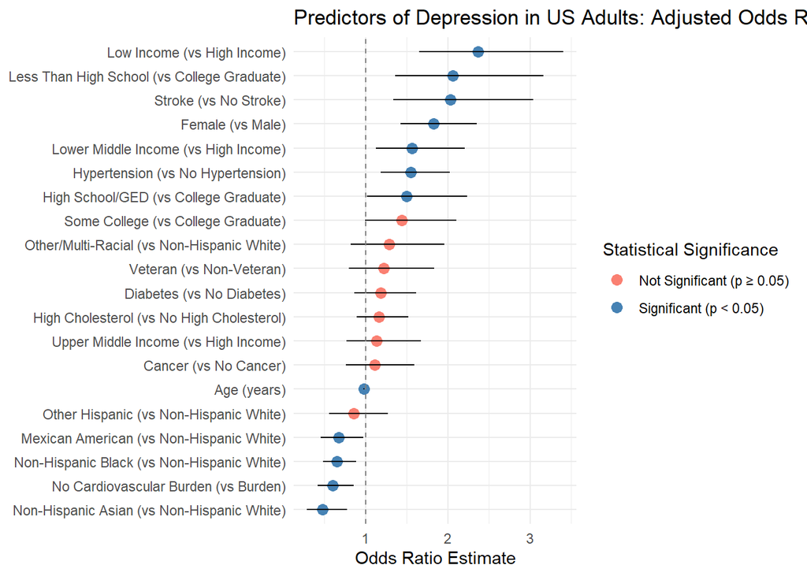

Figure 1: Adjusted Odds Ratios for Depression Predictors

Figure 2 presents the receiver operating characteristic (ROC) curve for the adjusted model. The model achieved an AUC of 0.701, indicating moderate discriminatory ability in distinguishing depressed from non-depressed participants.

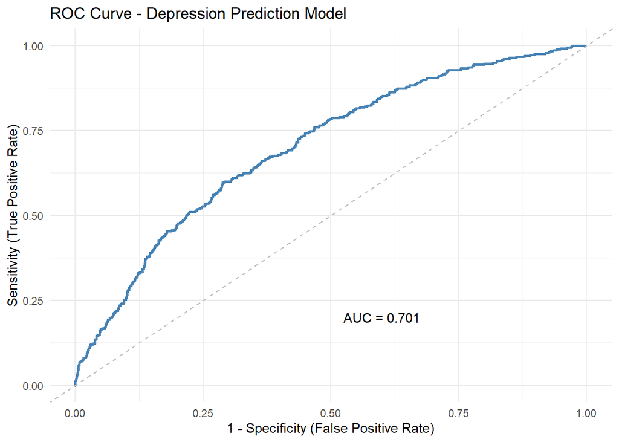

Figure 2: ROC Curve for Adjusted Logistic Regression Model (AUC = 0.701)

## Discussion

Overall, the lack of a statistically significant result for veteran status is not a failure and there are a few explanations for why this may be the case. The healthy soldier effect is one such explanation, that veterans are selected from a pool of already fit individuals who are likely to have comparative rates of depression to the general public despite having endured intense periods of mental and physical hardship during their military service. Additional analyses on stratified subgroups could be done to investigate whether there are differences between veterans of different eras and combat status. Veterans from the WWII era may have varied rates of depression than those who served during Vietnam or the wars on global terror in Iraq and Afghanistan. Therefore, there is still much to explore when it comes to identifying groups of veterans who are at higher-risk of developing depression.

## Limitations

This analysis had a number of limitations in its design and scope. The NHANES cross-sectional design only provided a snapshot of depression prevalence of the population tested and therefore is not enough to establish causality or temporal relationships. Additionally, using listwise deletion for missing data values meaningfully reduced the sample size from the full dataset. The rows removed may have been distinct from those remaining in the sample. Another limitation was the reliance on self-reported data. Veteran status, most health conditions, and PHQ-9 scores relied on participants self-reported responses and could have been influenced by self-report bias. The PHQ-9 threshold itself was another limitation as the binary cutoff of >= 10, discards variation in symptom severity and may misclassify individuals near the threshold. Finally, the veteran sample size of 439 limited statistical power to detect modest effects if they existed.

## Conclusion

Veteran status was not found to be a significant independent predictor of depression despite exposure to physical and mental stressors related to their service. However, other strong predictors were discovered through this analysis including low income, female gender, and stroke history. Age was found to have a slightly protective effect on depression. Other serious medical conditions like cancer and diabetes were not significant for predicting depression. For future analyses, separating veterans by the conflicts they served in or combat status would provide a more nuanced understanding of the factors that influence veterans’ mental health. Based on this analysis, using socioeconomic factors like income and education may be more actionable for identifying groups at higher risk for developing depression.

## References

Michal, M. (2019). Income and education predict elevated depressive symptoms in the general population: Results from the Gutenberg health study. BMC Public Health, 19(1), 430. https://doi.org/10.1186/s12889-019-6730-4

Vives-Bauza, C. (2025). Stroke survivors have almost three times higher risk of depression: A systematic review and meta-analysis. Journal of Clinical Medicine, 14(23), 8410. https://doi.org/10.3390/jcm14238410